# #TidyTuesday 3 / 17.9.2019: Week 38 US National Parks

novica

17/9/2019

## *Post hoc* synopsis

Оваа недела се посветивме повеќе кон начинот на пишување `ggplot2` код, имено, дали сите естетики се подесуваат со еден повик до `aes` или секоја посебно. Слично пракса може да се примени и за други `ggplot2` фунцкии коишто доколку ги повикаме повторно не се во конфликт со претходниот код. Такви се на пример `labs` или `theme` (примери подолу). Слично може да се примени и со `dplyr::filter`, каде што често, но не секогаш, може да филтрираме податоци со синтаксата `filter(x="x", y="y")` или `filter(x="a") %>% filter(y="b")`. Ова е интересно од аспект на читливоста на кодот и иако бара повеќе пишување, долгата форма (со посебен `aes` за секоја естетика) можеби е подостапна за нови корисници.

Други новини во овој документ се однесуваат на стилизирање на `ggplot2` графици, со основни функции или додатни пакети (`ggridges`).

## Резиме

- `.Rmd` (`R Markdown`) е околината во која ќе работиме
- Нов `R Notebook`: Мени: `File -> New File -> R notebook`
- Корисни кратенки:
  - code chunks (`ctrl+alt+i`)
  - pipes `%>%` (`ctrl+shift+m`)
  - assignment `<-` (`alt+-`)
  - `view()`

## Pipes expained, maybe

> This is how I explain the ‘pipe’ to [#rstats](https://twitter.com/hashtag/rstats?src=hash&ref_src=twsrc%5Etfw) newbies… [pic.twitter.com/VdAFTLzijy](https://t.co/VdAFTLzijy)

> — We are R-Ladies (@WeAreRLadies) [September 13, 2019](https://twitter.com/WeAreRLadies/status/1172576445794803713?ref_src=twsrc%5Etfw)

## Нов dataset

TidyTuesday 38: податоци од националните паркови во САД

> The [@R4DScommunity](https://twitter.com/R4DScommunity?ref_src=twsrc%5Etfw) welcomes you to week 38 of [#TidyTuesday](https://twitter.com/hashtag/TidyTuesday?src=hash&ref_src=twsrc%5Etfw)! We're exploring National Park Visits!!  
> 📁 https://t.co/sElb4fcv3u  
> 🗞 https://t.co/uKMrTmKokT[#r4ds](https://twitter.com/hashtag/r4ds?src=hash&ref_src=twsrc%5Etfw) [#tidyverse](https://twitter.com/hashtag/tidyverse?src=hash&ref_src=twsrc%5Etfw) [#rstats](https://twitter.com/hashtag/rstats?src=hash&ref_src=twsrc%5Etfw) [#dataviz](https://twitter.com/hashtag/dataviz?src=hash&ref_src=twsrc%5Etfw) [pic.twitter.com/92S7a7mzuj](https://t.co/92S7a7mzuj)

> — Thomas Mock 👨🏼 💻 (@thomas_mock) [September 16, 2019](https://twitter.com/thomas_mock/status/1173586589462740994?ref_src=twsrc%5Etfw)

## Брз и бавен ggplot

### Вообичаено:

```r
ggplot(my_data,
 aes(var1, y = var2, col = var3)) +
  geom_point() +
  ggtitle("My Title") +
  labs(x = "the x label",
   y = "the y label",
   col = "legend title")
```

(извор:[EvaMaeRey](https://github.com/EvaMaeRey/little_flipbooks_library/tree/master/minimal_example))

### Бавно:

```r
ggplot(data = my_data) +
  aes(x = var1) +
  labs(x = "the x label") +
  aes(y = var2) +
  labs(y = "the y label") +
  geom_point() +
  aes(col = var3) +
  labs(col = "legend title") +
  labs(title = "My title")
```

## Ѕирни ги податоците со glimpse

```r
library(tidyverse)
library(dplyr)

park_visits <- readr::read_csv("https://raw.githubusercontent.com/rfordatascience/tidytuesday/master/data/2019/2019-09-17/national_parks.csv")

glimpse(park_visits)
```

```
## Rows: 21,560
## Columns: 12
## $ year              <chr> "1904", "1941", "1961", "1935", "1982", "1919", "19…
## $ gnis_id           <chr> "1163670", "1531834", "2055170", "1530459", "277263…
## $ geometry          <chr> "POLYGON", "MULTIPOLYGON", "MULTIPOLYGON", "MULTIPO…
## $ metadata          <chr> NA, NA, NA, NA, NA, NA, NA, NA, NA, NA, NA, NA, NA,…
## $ number_of_records <dbl> 1, 1, 1, 1, 1, 1, 1, 1, 1, 1, 1, 1, 1, 1, 1, 1, 1, …
## $ parkname          <chr> "Crater Lake", "Lake Roosevelt", "Lewis and Clark",…
## $ region            <chr> "PW", "PW", "PW", "PW", "PW", "NE", "IM", "NE", "IM…
## $ state             <chr> "OR", "WA", "WA", "WA", "CA", "ME", "TX", "MD", "TX…
## $ unit_code         <chr> "CRLA", "LARO", "LEWI", "OLYM", "SAMO", "ACAD", "AM…
## $ unit_name         <chr> "Crater Lake National Park", "Lake Roosevelt Nation…
## $ unit_type         <chr> "National Park", "National Recreation Area", "Natio…
## $ visitors          <dbl> 1500, 0, 69000, 2200, 468144, 64000, 448000, 738700…
```

## Вкупен број на посетители по години

```r
pv_grouped <- park_visits %>%
  filter(unit_type == "National Park") %>%
  filter(!year == "Total") %>%
  group_by(year) %>%
  summarise_at(.vars = vars("visitors"),
    .funs = list("visitors_per_year"=sum)) %>%
  mutate(year = as.numeric(year))
pv_grouped
```

| year | visitors_per_year |
| --- | --- |
| 1904 | 120690 |
| 1905 | 140954 |
| 1906 | 30569 |
| 1907 | 32935 |
| 1908 | 42768 |
| 1909 | 60899 |
| 1910 | 173416 |
| 1911 | 193757 |
| 1912 | 197884 |
| 1913 | 216403 |

[output cut: 103 more lines]

Графички, горната табела може да ја прикажеме на следниот начин:

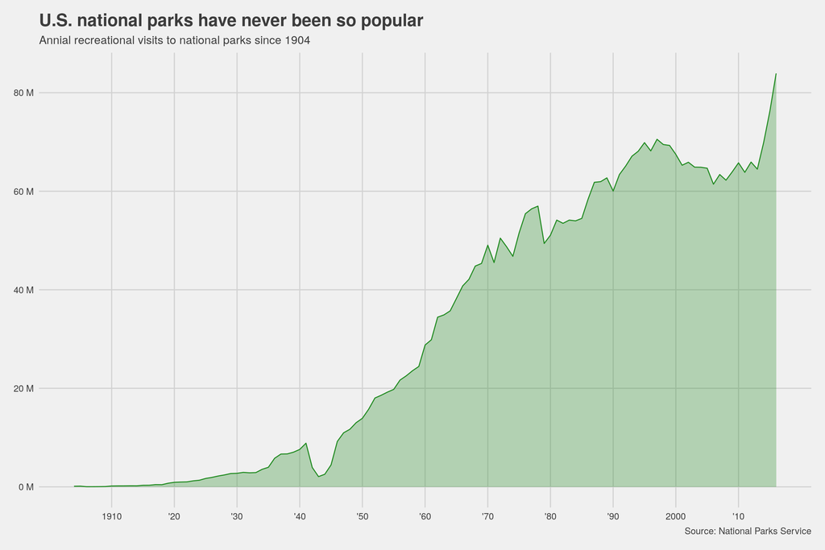

```r
 ggplot(data = pv_grouped) +
    aes(x = year) +
    aes(y = visitors_per_year / 10^6) +
    geom_line(color = "forestgreen") +
    geom_area(alpha = .3, fill = "forestgreen") +
    scale_y_continuous(labels = scales::unit_format(unit = "M")) +
    scale_x_continuous(breaks = seq(1910, 2016, 10),
      labels = c(1910, paste("'", seq(20, 90, 10), sep = ""), 2000, "'10")) +
    labs(x="") +
    labs(y="") +
    labs(title="U.S. national parks have never been so popular") +
    labs(subtitle="Annial recreational visits to national parks since 1904") +
    labs(caption="Source: National Parks Service") +
    ggthemes::theme_fivethirtyeight()
```

## Најдобрите 10 паркови

```r
top10 <- park_visits %>%
  filter(year == "Total") %>%
  arrange(desc(visitors)) %>%
  top_n(n = 10, wt=visitors)

pv2 <- park_visits %>%
  filter(!year == "Total") %>%
  select(year, unit_name, visitors) %>%
  group_by(year) %>%
  mutate(year_rank = rank(-visitors)) %>%
  ungroup %>%
  mutate(year = as.numeric(year)) %>%
  arrange(year, year_rank)

pv2_top10 <- filter(.data = pv2, unit_name %in% top10$unit_name)

pv2_top10
```

| year | unit_name | visitors | year_rank |
| --- | --- | --- | --- |
| 1931 | Great Smoky Mountains National Park | 154000 | 8.0 |
| 1932 | Colonial National Historical Park | 400000 | 2.0 |
| 1932 | Great Smoky Mountains National Park | 300000 | 3.0 |
| 1933 | Great Smoky Mountains National Park | 375000 | 1.0 |
| 1933 | Colonial National Historical Park | 66418 | 14.0 |
| 1934 | Great Smoky Mountains National Park | 420000 | 2.0 |
| 1934 | Colonial National Historical Park | 58303 | 25.0 |
| 1935 | Great Smoky Mountains National Park | 500000 | 2.0 |
| 1935 | Colonial National Historical Park | 367172 | 5.0 |
| 1936 | Lincoln Memorial | 857441 | 1.5 |

[output cut: 641 more lines]

И графички

[figure not shown]

```r
library(ggridges)
ord <- top10$unit_name[order(top10$visitors, decreasing = FALSE)]
lbl <- str_remove(ord, "National Park")

ggplot(data = pv2_top10) +
  aes(x = year) +
  aes(y = unit_name) +
  aes(fill = unit_name) +
  aes(group = unit_name) +
  aes(height = visitors) +
  aes(scale = .0000001) +
  ggridges::geom_ridgeline(alpha = .5) +
  theme_ridges() +
  labs(y = "") +
  labs(x = "") +
  labs(title = "National park visitors per year") +
  labs(subtitle = "The twenty most-visited parks overall") +
  # theme(axis.text.y = element_text(size = 14)) +
  scale_y_discrete(limits = ord, labels = lbl) +
  scale_fill_cyclical(limits = ord, values = c("dodgerblue", "forestgreen")) +
  scale_x_continuous(
    limits = c(1950, 2016),
    breaks = seq(1950, 2016, 10),
    labels = c("1950", "'60", "'70", "'80", "'90", "2000", "'10")
  ) +
  ggthemes::theme_fivethirtyeight()
```